# Coursework 1: Forecasting Google Trends Interest in Drake

MTH6139 Time Series

Nathaniel Aweseh-Boateng

20 March 2026

# Introduction

In this project, I explore a time series of Google Trends search interest for the hip-hop artist Drake in Great Britain. The aim of this project, is to, in the manner of a strategist or promoter within his team preparing for a rollout or tour, observe the behaviour of this series through time, before using Meta’s Prophet forecasting system to then forecast future trends in his search interest.

The first chart produced suggests that the series is quite irregular, as we have most observations in this period at a fairly low level, but with several clear, sharp spikes. At first glance, no seasonal pattern is easily deductible from the plot of this data alone.

# Preparing the Data

```r
drake_data <- read.csv("data/time_series_GB_20210320-1217_20260320-1217.csv")

drake_prophet_data <- data.frame(
  ds = as.Date(drake_data$Time),
  y = drake_data$Drake
)

head(drake_prophet_data)
```

```
##           ds  y
## 1 2021-03-01 23
## 2 2021-04-01 19
## 3 2021-05-01 22
## 4 2021-06-01 17
## 5 2021-07-01 20
## 6 2021-08-01 22
```

We observe that this dataset contains 61 observations taken monthly from March 2021 to March 2026.

# Initial Plot of The Series

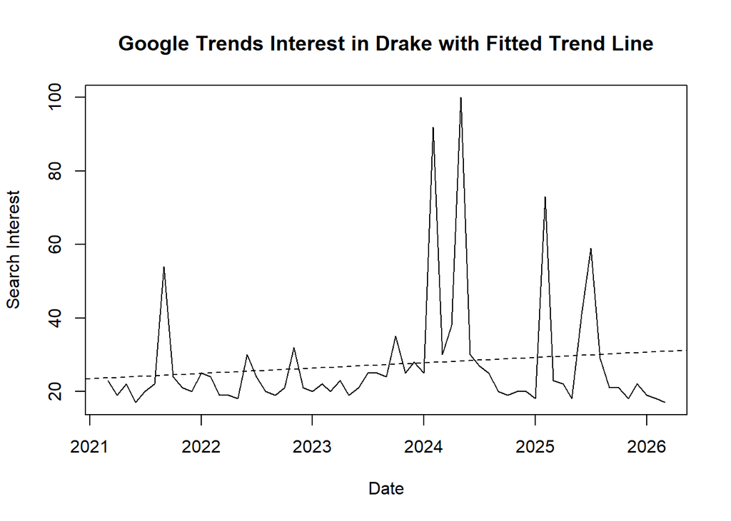

```r
plot(
  drake_prophet_data$ds,
  drake_prophet_data$y,
  type = "l",
  main = "Google Trends Interest in Drake with Fitted Trend Line",
  xlab = "Date",
  ylab = "Search Interest"
)

abline(lm(y ~ ds, data = drake_prophet_data), lty = 2)
```

We get a simple fitted trend line, which shows a slight upward movement over time, but we can see that the series is dominated by irregular spikes, so that overall upward movement has not been smooth.

# Prophet Forecast

This forecast should however be treated with caution. The plot shows that the predicted values fall in a very sharp manner, eventually becoming negative, which is difficult to interpret when it comes to Google Trends search interest. This suggests that, while the model has indeed produced a forecast, the default fit of this model may not describe the future behaviour of this series in a realistic manner.

```r
library(prophet)
drake_prophet_model <- prophet(drake_prophet_data)
```

```
## Disabling weekly seasonality. Run prophet with weekly.seasonality=TRUE to override this.
```

```
## Disabling daily seasonality. Run prophet with daily.seasonality=TRUE to override this.
```

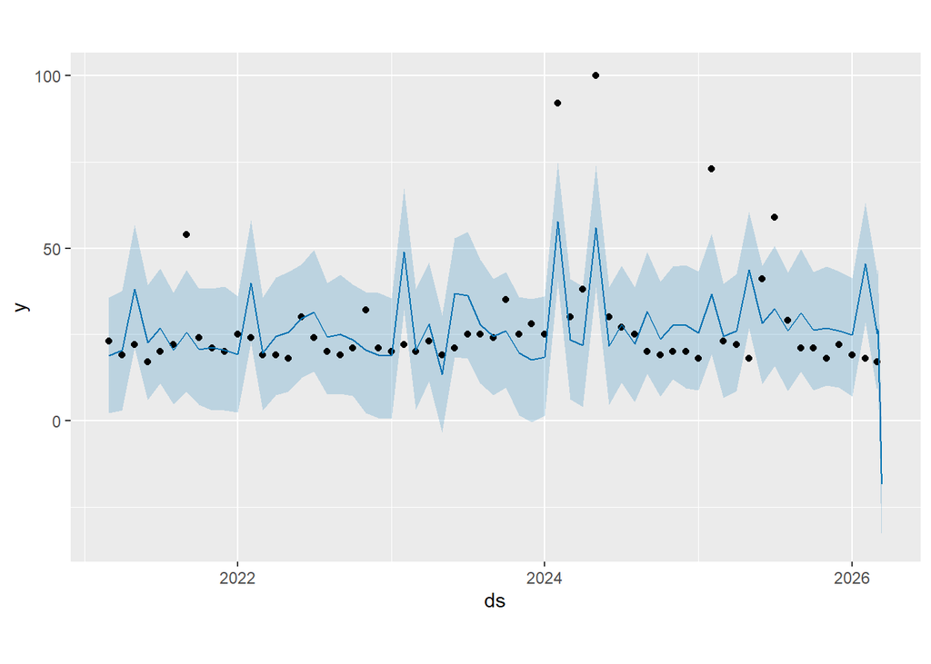

```r
drake_future_dates <- make_future_dataframe(drake_prophet_model, periods = 12)

drake_forecast <- predict(drake_prophet_model, drake_future_dates)

plot(drake_prophet_model, drake_forecast)
```

# Forecast Values

To inspect the forecast more closely, I looked at the predicted values for the 12 future periods. This makes it easier to see the size and direction of the forecast, rather than relying only on the plot.

```r
tail(drake_forecast[, c("ds", "yhat", "yhat_lower", "yhat_upper")], 12)
```

```
##            ds        yhat  yhat_lower yhat_upper
## 62 2026-03-02  26.6325768   9.6299192  42.559944
## 63 2026-03-03  26.2207253   9.2126463  43.632062
## 64 2026-03-04  24.2220698   7.0306495  42.495334
## 65 2026-03-05  20.8661654   3.4464501  37.127009
## 66 2026-03-06  16.4254924  -0.5142716  32.603032
## 67 2026-03-07  11.2048124  -5.8130751  28.012473
## 68 2026-03-08   5.5295206 -10.8805967  22.851198
## 69 2026-03-09  -0.2666375 -18.0518726  16.940874
## 70 2026-03-10  -5.8540988 -23.8110679  12.007131
## 71 2026-03-11 -10.9198695 -27.5320569   6.508409
## 72 2026-03-12 -15.1793728 -32.3644235   1.511885
## 73 2026-03-13 -18.3873782 -34.1460975  -1.360503
```

# Comparing With A Second Forecast

As such, I elected to I fit a second Prophet model with weekly seasonality switched on. I chose to do this as the default model output stated that weekly seasonality had been disabled.

The second forecast produced a far more realistic result when compared with the first. Here, the forecast values remained positive and within a more plausible range. For this reason, I consider the second forecast to be more useful for interpreting possible future search interest in Drake.

```r
drake_prophet_model_weekly <- prophet(
  drake_prophet_data,
  weekly.seasonality = TRUE
)
```

```
## Disabling daily seasonality. Run prophet with daily.seasonality=TRUE to override this.
```

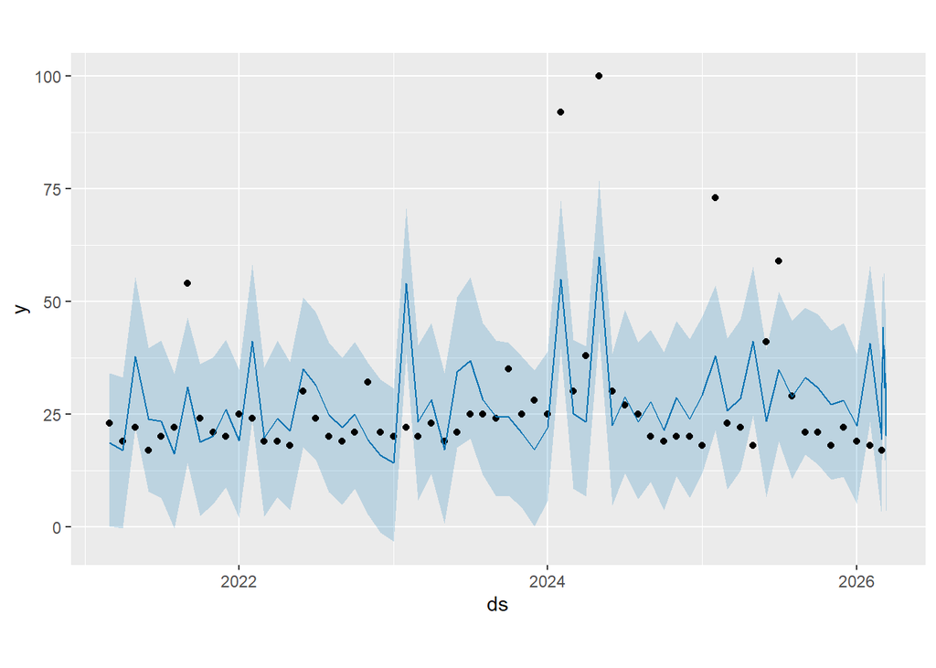

```r
drake_future_dates_weekly <- make_future_dataframe(
  drake_prophet_model_weekly,
  periods = 12
)

drake_forecast_weekly <- predict(
  drake_prophet_model_weekly,
  drake_future_dates_weekly
)

plot(drake_prophet_model_weekly, drake_forecast_weekly)
```

```r
tail(drake_forecast_weekly[, c("ds", "yhat", "yhat_lower", "yhat_upper")], 12)
```

```
##            ds     yhat yhat_lower yhat_upper
## 62 2026-03-02 31.92828  14.710888   49.93236
## 63 2026-03-03 37.69025  21.625838   55.35146
## 64 2026-03-04 44.25722  27.647745   60.92000
## 65 2026-03-05 37.28199  20.519510   54.37864
## 66 2026-03-06 40.25394  23.192006   56.80993
## 67 2026-03-07 39.42402  22.460007   56.29565
## 68 2026-03-08 30.84785  14.558974   49.62593
## 69 2026-03-09 34.03161  15.398857   51.09800
## 70 2026-03-10 31.76988  14.748424   48.26245
## 71 2026-03-11 31.89584  15.723037   49.14501
## 72 2026-03-12 20.20087   3.665736   37.86007
## 73 2026-03-13 20.24251   2.384497   36.38493
```

# Conclusion

This project sought to explore Google Trends search interest for Drake in Great Britain using Meta’s Prophet forecasting system. Considering the initial observations made from the data, as well as the results from both forecasts, we can conclude that it is essential to check model output, and consider the impact of model settings. No doubt, the irregular nature of the series and lack of obvious seasonality influenced our initial choices, but we see that the second forecast that assumed weekly seasonality in fact produced a more plausible forecast. A crucial lesson, then, to take, is that model output should always be carefully checked.